# Advanced Bioinformatics Assignment 2026

K25163714/M2202133

2026-04-13

# Task 3.1

Using the sum function and the : operator will create a sequence of numbers from 5 to 55 which should find the sum of all integers between 5 and 55

```r
sum(5:55)
```

```
## [1] 1530
```

# Task 3.2

sumfun() will use the created parameter n and will calculate the sum of the integers from 5 to the value of n set, in this case 10, 20 and 100

```r
sumfun <- function(n) {sum(5:n)}
sumfun(10)
```

```
## [1] 45
```

```r
sumfun(20)
```

```
## [1] 200
```

```r
sumfun(100)
```

```
## [1] 5040
```

# Task 3.3

I used the for loop to calcuate the first 12 terms of the Fibonnaci sequence which starts with 1,1

```r
fibonacci <- numeric(12)
fibonacci[1:2] <- 1
for (i in 3:12) {
  fibonacci[i] <- fibonacci[i-1] + fibonacci[i-2]
}
fibonacci
```

```
##  [1]   1   1   2   3   5   8  13  21  34  55  89 144
```

# Task 3.4

ggplot2 is used to create a boxplot looking at miles per gallon (mpg) by the number of gears from the mtcars dataset withe the number of gears shown by the different colours

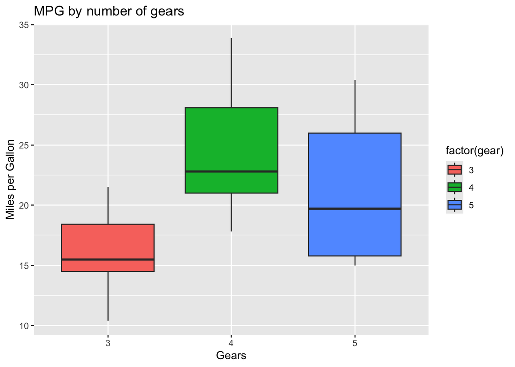

```r
library(ggplot2)
ggplot(mtcars, aes(x = factor(gear), y = mpg, fill = factor(gear))) + geom_boxplot() + labs(title = "MPG by number of gears", x = "Gears", y = "Miles per Gallon")
```

# Task 3.5

A linear model was created to show the relationship between speed and breaking distance using the lm() function with speed measured in mph and the distance measured in feet.

```r
data(cars)
fit <- lm(dist ~ speed, data = cars)
summary(fit)
```

```
##
## Call:
## lm(formula = dist ~ speed, data = cars)
##
## Residuals:
##     Min      1Q  Median      3Q     Max
## -29.069  -9.525  -2.272   9.215  43.201
##
## Coefficients:
##             Estimate Std. Error t value Pr(>|t|)
## (Intercept) -17.5791     6.7584  -2.601   0.0123 *
## speed         3.9324     0.4155   9.464 1.49e-12 ***
## ---
## Signif. codes:  0 '***' 0.001 '**' 0.01 '*' 0.05 '.' 0.1 ' ' 1
##
## Residual standard error: 15.38 on 48 degrees of freedom
## Multiple R-squared:  0.6511, Adjusted R-squared:  0.6438
## F-statistic: 89.57 on 1 and 48 DF,  p-value: 1.49e-12
```

The slope of the line is 3.932 which means there is around 4 feet of stopping distance for every 1mph of speed with a standard error of 0.4155 The intercept is -17.579 at a speed of 0 with a standard error of 6.7584

# Task 3.6

The breaking distance against the speed calculations from Task 3.5 were plotted in a linear fit using ggplot

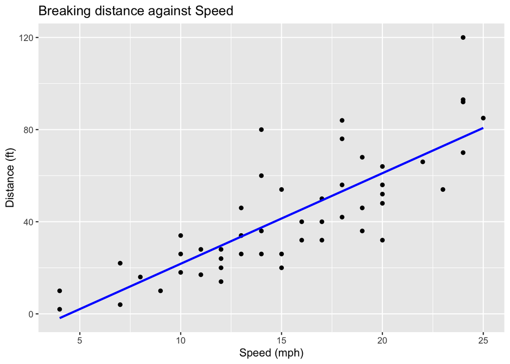

```r
ggplot(cars, aes(x = speed, y = dist)) + geom_point() + geom_smooth(method = "lm", se = FALSE, color = "blue") + labs(title = "Breaking distance against Speed", x = "Speed (mph)", y = "Distance (ft)")
```

# Task 3.7

```r
data(cars)
fit2 <- lm(dist ~ speed + I(speed^2), data = cars)
summary(fit2)
```

```
##
## Call:
## lm(formula = dist ~ speed + I(speed^2), data = cars)
##
## Residuals:
##     Min      1Q  Median      3Q     Max
## -28.720  -9.184  -3.188   4.628  45.152
##
## Coefficients:
##             Estimate Std. Error t value Pr(>|t|)
## (Intercept)  2.47014   14.81716   0.167    0.868
## speed        0.91329    2.03422   0.449    0.656
## I(speed^2)   0.09996    0.06597   1.515    0.136
##
## Residual standard error: 15.18 on 47 degrees of freedom
## Multiple R-squared:  0.6673, Adjusted R-squared:  0.6532
## F-statistic: 47.14 on 2 and 47 DF,  p-value: 5.852e-12
```

Once these calculations are complete and it has been identified using linear regression we can then use ggplot to plot the data points along with the line of best fit for the relationship

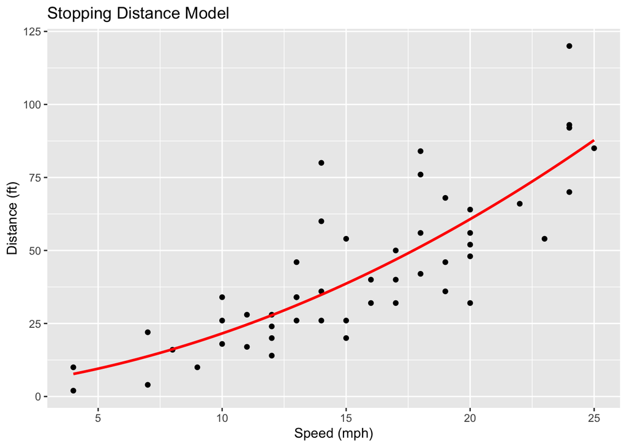

```r
ggplot(cars, aes(x = speed, y = dist)) +
  geom_point() +
  geom_smooth(method = "lm", formula = y ~ x + I(x^2), se = FALSE, color = "red") +
  labs(title = "Stopping Distance Model", x = "Speed (mph)", y = "Distance (ft)")
```